[output not shown]

```python
# setting up IPython Notebook so that it displays nicely
# you can safely skip this cell...
%pylab inline
pylab.rcParams['figure.figsize'] = (10.0, 5.0)
from pyannote.core.notebook import set_notebook_crop, Segment
set_notebook_crop(Segment(0, 30))
```

# Evaluation corpus

Experiments are performed on **[The Big Bang Theory](http://tvd.niderb.fr/series/)** subset of the **[TVD](http://tvd.niderb.fr/)** corpus.  
Instructions to reproduce this corpus locally are provided on **[TVD website](http://tvd.niderb.fr/corpus/)**.  
The only prerequisite is that you acquire DVDs for the first season.

```python
from tvd import TheBigBangTheory
dataset = TheBigBangTheory('/Volumes/data/tvd/')
```

[output not shown]

Experiments are conducted on the **first six episodes** of the first season of **The Big Bang Theory** TV series.  
Indeed, manual speech turns annotations are only available for these very episodes.

```python
sixFirstEpisodes = dataset.episodes[:6]
for episode in sixFirstEpisodes:
    print episode
```

```
TheBigBangTheory.Season01.Episode01
TheBigBangTheory.Season01.Episode02
TheBigBangTheory.Season01.Episode03
TheBigBangTheory.Season01.Episode04
TheBigBangTheory.Season01.Episode05
TheBigBangTheory.Season01.Episode06
```

For illustration purposes, we will only focus on the very first episode of the series.

```python
episode = sixFirstEpisodes[0]
print episode
```

```
TheBigBangTheory.Season01.Episode01
```

## Audio tracks

Once [reproduced](http://tvd.niderb.fr/corpus/) locally, the **TVD** corpus provides audio tracks for every episode in every language available on DVDs.

```python
english = dataset.path_to_audio(episode, language='en')
french = dataset.path_to_audio(episode, language='fr')
print 'English soundtrack:', english
print 'French soundtrack:', french
```

```
English soundtrack: /Volumes/data/tvd//TheBigBangTheory/dvd/rip/audio/TheBigBangTheory.Season01.Episode01.en.wav
French soundtrack: /Volumes/data/tvd//TheBigBangTheory/dvd/rip/audio/TheBigBangTheory.Season01.Episode01.fr.wav
```

## Subtitles

```python
english = dataset.path_to_subtitles(episode, language='en')
print 'English subtitles:', english
```

```
English subtitles: /Volumes/data/tvd//TheBigBangTheory/dvd/rip/subtitles/TheBigBangTheory.Season01.Episode01.en.srt
```

**pyannote.parser** provides a SRT parser that takes care of dividing (**split=True**) subtitles that cover multiple dialogue lines from several speaker, and allottes to each line a duration proportional to their number of words (**duration=True**).

```python
from pyannote.parser.srt import SRTParser
subtitles = SRTParser(split=True, duration=True).read(english)
subtitles
```

[figure not shown]

## Transcript

While subtitles provides coarse dialogue transcription with timestamps, transcripts, on the other side, provides exact dialogue transcription but no timing information other than the chronological order.

```python
transcript = dataset.get_resource('transcript', episode)
transcript
```

[figure not shown]

## Reference

**The Big Bang Theory** **TVD** plugin provides a resource called **speaker** containing manual annotation of the audio track.

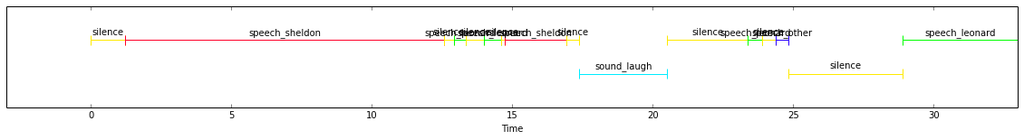

```python
manual_annotation = dataset.get_resource('speaker', episode)
manual_annotation
```

Manual annotation provides all sorts of labels...

```python
all_labels = manual_annotation.labels()
all_labels
```

```
['music_titlesong',
 'silence',
 'sound_laugh',
 'sound_laughclap',
 'sound_other',
 'speech_howard',
 'speech_leonard',
 'speech_other',
 'speech_overlapping',
 'speech_penny',
 'speech_raj',
 'speech_sheldon']
```

... but only **speech** regions are of interest to us:

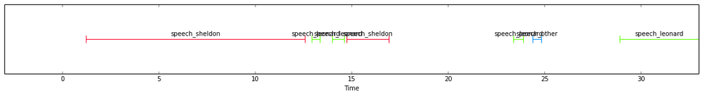

```python
labels = [label for label in all_labels if label.startswith('speech_')]
speech_regions = manual_annotation.subset(set(labels))
speech_regions
```

Among those **speech** regions, we focus on the main 5 characters.

```python
speech_regions.labels()
```

```
['speech_howard',
 'speech_leonard',
 'speech_other',
 'speech_overlapping',
 'speech_penny',
 'speech_raj',
 'speech_sheldon']
```

All other speech turns are marked as **OTHER**

```python
main_characters = ['sheldon', 'leonard', 'penny', 'howard', 'raj']
mapping = {label: label[7:].upper() if label[7:] in main_characters else 'OTHER'
               for label in labels}
mapping
```

```
{'speech_howard': 'HOWARD',
 'speech_leonard': 'LEONARD',
 'speech_other': 'OTHER',
 'speech_overlapping': 'OTHER',
 'speech_penny': 'PENNY',
 'speech_raj': 'RAJ',
 'speech_sheldon': 'SHELDON'}
```

[figure not shown]

```python
reference = speech_regions.translate(mapping)
reference
```

There you go: we now have our shiny speaker identification reference!